# **Analyzing the Evolution of NBA Game Scores and Three-Point Shooting Trends Over Time**

Vinay Gundu, Contribution 100%

# **Introduction**

NBA games are seeing record-breaking scores, with results like 125:130 or halftime scores of 70:75, which used to resemble full-game scores in the past. To verify this, I want to analyze historical **data** to determine if scoring growth has been consistent and linear over the years. Additionally, there's a perception that basketball has shifted towards prioritizing three-point shooting, possibly influenced by players like Stephen Curry. It's important to investigate whether there's been an increase in the number of three-point attempts and successes over time, and see how the game has evolved over time.

# **Data Curation**

The dataset I will be using is this https://www.kaggle.com/datasets/wyattowalsh/basketball?resource=download. This dataset includes 65,000+ games (every game since the inaugural 1946-47 NBA season) and Box Scores for over 95% of all games. These are very useful for my project so I can isolate point totals in games, as well as 3 pointers made in a single game, which I can use to investigate the trends aforementioned. Specifically, I worked with the game.csv file.

```python
import pandas as pd


pd.set_option('display.max_columns', None)

df = pd.read_csv('game.csv', parse_dates=['game_date'])

df.shape
```

```
(65698, 55)
```

```python
df.head()
```

|  | season_id | team_id_home | team_abbreviation_home | team_name_home | game_id | game_date | matchup_home | wl_home | min | fgm_home | fga_home | fg_pct_home | fg3m_home | fg3a_home | fg3_pct_home | ftm_home | fta_home | ft_pct_home | oreb_home | dreb_home | reb_home | ast_home | stl_home | blk_home | tov_home | pf_home | pts_home | plus_minus_home | video_available_home | … |
| --- | --- | --- | --- | --- | --- | --- | --- | --- | --- | --- | --- | --- | --- | --- | --- | --- | --- | --- | --- | --- | --- | --- | --- | --- | --- | --- | --- | --- | --- | --- |
| 0 | 21946 | 1610610035 | HUS | Toronto Huskies | 24600001 | 1946-11-01 | HUS vs. NYK | L | 0 | 25.0 | NaN | NaN | NaN | NaN | NaN | 16.0 | 29.0 | 0.552 | NaN | NaN | NaN | NaN | NaN | NaN | NaN | NaN | 66.0 | -2 | 0 | … |
| 1 | 21946 | 1610610034 | BOM | St. Louis Bombers | 24600003 | 1946-11-02 | BOM vs. PIT | W | 0 | 20.0 | 59.0 | 0.339 | NaN | NaN | NaN | 16.0 | NaN | NaN | NaN | NaN | NaN | NaN | NaN | NaN | NaN | 21.0 | 56.0 | 5 | 0 | … |
| 2 | 21946 | 1610610032 | PRO | Providence Steamrollers | 24600002 | 1946-11-02 | PRO vs. BOS | W | 0 | 21.0 | NaN | NaN | NaN | NaN | NaN | 17.0 | NaN | NaN | NaN | NaN | NaN | NaN | NaN | NaN | NaN | NaN | 59.0 | 6 | 0 | … |
| 3 | 21946 | 1610610025 | CHS | Chicago Stags | 24600004 | 1946-11-02 | CHS vs. NYK | W | 0 | 21.0 | NaN | NaN | NaN | NaN | NaN | 21.0 | NaN | NaN | NaN | NaN | NaN | NaN | NaN | NaN | NaN | 20.0 | 63.0 | 16 | 0 | … |
| 4 | 21946 | 1610610028 | DEF | Detroit Falcons | 24600005 | 1946-11-02 | DEF vs. WAS | L | 0 | 10.0 | NaN | NaN | NaN | NaN | NaN | 13.0 | NaN | NaN | NaN | NaN | NaN | NaN | NaN | NaN | NaN | NaN | 33.0 | -17 | 0 | … |

```python
df.tail()
```

|  | season_id | team_id_home | team_abbreviation_home | team_name_home | game_id | game_date | matchup_home | wl_home | min | fgm_home | fga_home | fg_pct_home | fg3m_home | fg3a_home | fg3_pct_home | ftm_home | fta_home | ft_pct_home | oreb_home | dreb_home | reb_home | ast_home | stl_home | blk_home | tov_home | pf_home | pts_home | plus_minus_home | video_available_home | … |
| --- | --- | --- | --- | --- | --- | --- | --- | --- | --- | --- | --- | --- | --- | --- | --- | --- | --- | --- | --- | --- | --- | --- | --- | --- | --- | --- | --- | --- | --- | --- |
| 65693 | 42022 | 1610612748 | MIA | Miami Heat | 42200403 | 2023-06-07 | MIA vs. DEN | L | 240 | 34.0 | 92.0 | 0.370 | 11.0 | 35.0 | 0.314 | 15.0 | 19.0 | 0.789 | 10.0 | 23.0 | 33.0 | 20.0 | 7.0 | 3.0 | 4.0 | 22.0 | 94.0 | -15 | 1 | … |
| 65694 | 42022 | 1610612748 | MIA | Miami Heat | 42200404 | 2023-06-09 | MIA vs. DEN | L | 240 | 35.0 | 78.0 | 0.449 | 8.0 | 25.0 | 0.320 | 17.0 | 20.0 | 0.850 | 8.0 | 29.0 | 37.0 | 23.0 | 2.0 | 3.0 | 15.0 | 19.0 | 95.0 | -13 | 1 | … |
| 65695 | 42022 | 1610612743 | DEN | Denver Nuggets | 42200405 | 2023-06-12 | DEN vs. MIA | W | 240 | 38.0 | 84.0 | 0.452 | 5.0 | 28.0 | 0.179 | 13.0 | 23.0 | 0.565 | 11.0 | 46.0 | 57.0 | 21.0 | 6.0 | 7.0 | 15.0 | 13.0 | 94.0 | 5 | 1 | … |
| 65696 | 32022 | 1610616834 | LBN | Team LeBron | 32200001 | 2023-02-19 | LBN vs. GNS | L | 221 | 79.0 | 132.0 | 0.598 | 17.0 | 60.0 | 0.283 | 0.0 | 0.0 | NaN | 13.0 | 32.0 | 45.0 | 49.0 | 7.0 | 2.0 | 10.0 | 5.0 | 175.0 | -9 | 1 | … |
| 65697 | 32022 | 1610616834 | LBN | Team LeBron | 32200001 | 2023-02-19 | LBN vs. GNS | L | 221 | 79.0 | 132.0 | 0.598 | 17.0 | 60.0 | 0.283 | 0.0 | 0.0 | NaN | 13.0 | 32.0 | 45.0 | 49.0 | 7.0 | 2.0 | 10.0 | 5.0 | 175.0 | -9 | 1 | … |

I wanted to remove outliers such as preseason and all star games, so I removed these as demonstrated below, and am only including regular season and playoff games

```python
df['season_type'].value_counts()
```

```
season_type
Regular Season    60192
Playoffs           3842
Pre Season         1536
All Star             65
All-Star             63
Name: count, dtype: int64
```

```python
df_games = df[df['season_type'].isin(['Regular Season', 'Playoffs'])]
df_games.shape
```

```
(64034, 55)
```

```python
df_games = df_games.loc[:, ['game_date', 'pts_home', 'pts_away', 'fg3m_home', 'fg3a_home', 'fg3m_away', 'fg3a_away']]
df_games.head()
```

|  | game_date | pts_home | pts_away | fg3m_home | fg3a_home | fg3m_away | fg3a_away |
| --- | --- | --- | --- | --- | --- | --- | --- |
| 0 | 1946-11-01 | 66.0 | 68.0 | NaN | NaN | NaN | NaN |
| 1 | 1946-11-02 | 56.0 | 51.0 | NaN | NaN | NaN | NaN |
| 2 | 1946-11-02 | 59.0 | 53.0 | NaN | NaN | NaN | NaN |
| 3 | 1946-11-02 | 63.0 | 47.0 | NaN | NaN | NaN | NaN |
| 4 | 1946-11-02 | 33.0 | 50.0 | NaN | NaN | NaN | NaN |

```python
df_games.insert(0, 'game_year', df_games['game_date'].dt.year)
df_games = df_games.drop('game_date', axis=1)
df_games.head()
```

|  | game_year | pts_home | pts_away | fg3m_home | fg3a_home | fg3m_away | fg3a_away |
| --- | --- | --- | --- | --- | --- | --- | --- |
| 0 | 1946 | 66.0 | 68.0 | NaN | NaN | NaN | NaN |
| 1 | 1946 | 56.0 | 51.0 | NaN | NaN | NaN | NaN |
| 2 | 1946 | 59.0 | 53.0 | NaN | NaN | NaN | NaN |
| 3 | 1946 | 63.0 | 47.0 | NaN | NaN | NaN | NaN |
| 4 | 1946 | 33.0 | 50.0 | NaN | NaN | NaN | NaN |

The addition of a 'game_year' column allows for easier analysis and visualization of trends over time. By extracting the year component from the 'game_date' column, each game's date is represented by just the year

```python
df_games.insert(3, 'total_score', df_games['pts_home'] + df_games['pts_away'])
df_games = df_games.drop(['pts_home', 'pts_away'], axis=1)
df_games.head()
```

|  | game_year | total_score | fg3m_home | fg3a_home | fg3m_away | fg3a_away |
| --- | --- | --- | --- | --- | --- | --- |
| 0 | 1946 | 134.0 | NaN | NaN | NaN | NaN |
| 1 | 1946 | 107.0 | NaN | NaN | NaN | NaN |
| 2 | 1946 | 112.0 | NaN | NaN | NaN | NaN |
| 3 | 1946 | 110.0 | NaN | NaN | NaN | NaN |
| 4 | 1946 | 83.0 | NaN | NaN | NaN | NaN |

# **Exploratory Data Analysis**

By computing the total score for each game and storing it in a separate column, we create a new feature that provides a concise representation of the game outcome.

```python
df_games['fg3_made'] = df_games['fg3m_home'] + df_games['fg3m_away']
df_games['fg3_attempts'] = df_games['fg3a_home'] + df_games['fg3a_away']
df_games['fg3_pct'] = df_games['fg3_made'] / df_games['fg3_attempts']
df_games = df_games.drop(['fg3m_home', 'fg3m_away', 'fg3a_home', 'fg3a_away'], axis=1)
df_games.head()
```

|  | game_year | total_score | fg3_made | fg3_attempts | fg3_pct |
| --- | --- | --- | --- | --- | --- |
| 0 | 1946 | 134.0 | NaN | NaN | NaN |
| 1 | 1946 | 107.0 | NaN | NaN | NaN |
| 2 | 1946 | 112.0 | NaN | NaN | NaN |
| 3 | 1946 | 110.0 | NaN | NaN | NaN |
| 4 | 1946 | 83.0 | NaN | NaN | NaN |

```python
df_games.sort_values('fg3_pct', ascending=False)
```

|  | game_year | total_score | fg3_made | fg3_attempts | fg3_pct |
| --- | --- | --- | --- | --- | --- |
| 18710 | 1985 | 231.0 | 2.0 | 0.0 | inf |
| 18486 | 1984 | 205.0 | 2.0 | 2.0 | 1.0 |
| 17966 | 1984 | 233.0 | 1.0 | 1.0 | 1.0 |
| 15776 | 1982 | 211.0 | 3.0 | 3.0 | 1.0 |
| 19696 | 1986 | 235.0 | 2.0 | 2.0 | 1.0 |
| ... | ... | ... | ... | ... | ... |
| 20260 | 1986 | 222.0 | 0.0 | 0.0 | NaN |
| 20475 | 1986 | 222.0 | 0.0 | 0.0 | NaN |
| 20556 | 1987 | 194.0 | 0.0 | 0.0 | NaN |
| 21927 | 1988 | 209.0 | 0.0 | 0.0 | NaN |
| 24960 | 1991 | 216.0 | 0.0 | 0.0 | NaN |

64034 rows × 5 columns

```python
df_games.query('fg3_attempts < fg3_made')
```

|  | game_year | total_score | fg3_made | fg3_attempts | fg3_pct |
| --- | --- | --- | --- | --- | --- |
| 18710 | 1985 | 231.0 | 2.0 | 0.0 | inf |

```python
df_games = df_games.drop(df_games.query('fg3_attempts < fg3_made').index)
df_games.sort_values('fg3_pct', ascending=False)
```

|  | game_year | total_score | fg3_made | fg3_attempts | fg3_pct |
| --- | --- | --- | --- | --- | --- |
| 20030 | 1986 | 239.0 | 2.0 | 2.0 | 1.0 |
| 18486 | 1984 | 205.0 | 2.0 | 2.0 | 1.0 |
| 22351 | 1988 | 216.0 | 2.0 | 2.0 | 1.0 |
| 23835 | 1990 | 192.0 | 3.0 | 3.0 | 1.0 |
| 20032 | 1986 | 225.0 | 1.0 | 1.0 | 1.0 |
| ... | ... | ... | ... | ... | ... |
| 20260 | 1986 | 222.0 | 0.0 | 0.0 | NaN |
| 20475 | 1986 | 222.0 | 0.0 | 0.0 | NaN |
| 20556 | 1987 | 194.0 | 0.0 | 0.0 | NaN |
| 21927 | 1988 | 209.0 | 0.0 | 0.0 | NaN |
| 24960 | 1991 | 216.0 | 0.0 | 0.0 | NaN |

64033 rows × 5 columns

```python
df_years = df_games.groupby('game_year')['total_score'].mean()
df_years
```

```
game_year
1946    129.507812
1947    140.691525
1948    151.726644
1949    160.364211
1950    161.536346
           ...
2019    222.167324
2020    225.256374
2021    221.364308
2022    225.166168
2023    229.712240
Name: total_score, Length: 77, dtype: float64
```

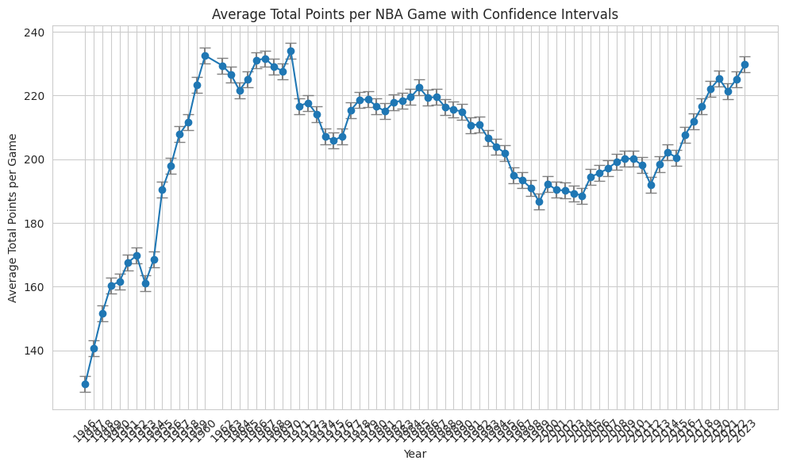

```python
import matplotlib.pyplot as plt

plt.figure(figsize=(10, 6))
plt.errorbar(df_years.index, df_years.values, yerr=df_years.sem(), fmt='-o', ecolor='gray', capsize=5)
plt.title('Average Total Points per NBA Game with Confidence Intervals')
plt.xlabel('Year')
plt.ylabel('Average Total Points per Game')
plt.grid(True)
plt.xticks(df_years.index, rotation=45)
plt.tight_layout()
plt.show()
```

```python
df_60s = df_games[df_games['game_year'] == 1964]
df_60s.head(5)
```

|  | game_year | total_score | fg3_made | fg3_attempts | fg3_pct |
| --- | --- | --- | --- | --- | --- |
| 5420 | 1964 | 217.0 | NaN | NaN | NaN |
| 5421 | 1964 | 223.0 | NaN | NaN | NaN |
| 5422 | 1964 | 233.0 | NaN | NaN | NaN |
| 5423 | 1964 | 242.0 | NaN | NaN | NaN |
| 5424 | 1964 | 212.0 | NaN | NaN | NaN |

```python
df_3pts = df_games.dropna(subset = ['fg3_made', 'fg3_attempts', 'fg3_pct'])
df_3pts.head()
```

|  | game_year | total_score | fg3_made | fg3_attempts | fg3_pct |
| --- | --- | --- | --- | --- | --- |
| 14165 | 1980 | 211.0 | 0.0 | 2.0 | 0.0 |
| 14166 | 1980 | 211.0 | 0.0 | 2.0 | 0.0 |
| 14167 | 1980 | 212.0 | 1.0 | 5.0 | 0.2 |
| 14169 | 1980 | 211.0 | 0.0 | 3.0 | 0.0 |
| 14170 | 1980 | 230.0 | 0.0 | 8.0 | 0.0 |

```python
df_3made = df_3pts.groupby('game_year')['fg3_made'].mean()
df_3made.head()
```

```
game_year
1980    0.200000
1981    0.833333
1982    1.268116
1983    1.121212
1984    1.147368
Name: fg3_made, dtype: float64
```

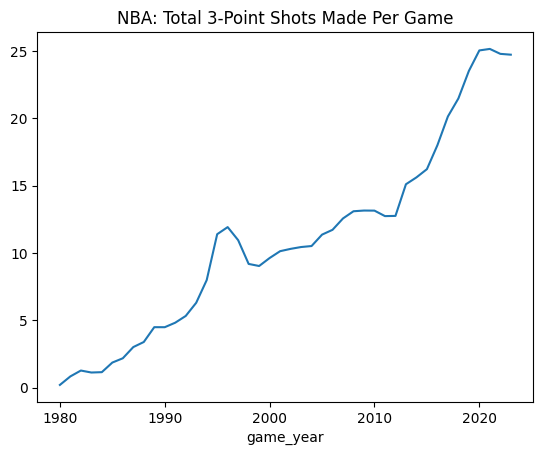

```python
df_3made.plot(title='NBA: Total 3-Point Shots Made Per Game')
```

Wow, a very clear trend is apparent. We can see a very positive relationship as the years have gone on in correlation with the number of 3-point shots made. For context, the average of 25 3-pointers made per game provides valuable insight into the prevalence and significance of long-range shooting in NBA gameplay. Given that each successful 3-pointer adds three points to a team's score, totaling 75 points for all 25 shots. In the context of 3-point shooting dynamics, the average of 25 3-pointers made per game in contemporary NBA games starkly contrasts with the landscape of the early 90s and 80s. During those eras, the total number of 3-pointers made per game typically ranged between 0 and 5. This significant shift over time reflects the evolution of basketball strategy and the increasing emphasis on long-range shooting as a fundamental aspect of offensive gameplay.

## **One Sample T-Test**

I want to do a one-sample t-test comparing the mean total scores for all years against a specific value. This can help determine if the mean total scores are significantly different from a particular benchmark or expectation. I have chosen a benchmark of 200. I chose 200 as a benchmark for total scores in NBA games because it represents a commonly observed threshold signifying a moderately high-scoring game, providing a meaningful point of comparison for evaluating scoring trends and deviations from typical scoring norms.

Null Hypothesis (H0): The mean total score for all years is 200.

```python
from scipy.stats import ttest_1samp


benchmark_value = 200


t_stat, p_value = ttest_1samp(df_years, benchmark_value)

alpha = 0.05

print("One-Sample t-test Results:")
print("Test Statistic (t-value):", t_stat)
print("P-value:", p_value)
```

```
One-Sample t-test Results:
Test Statistic (t-value): 1.754243484355025
P-value: 0.08341971410683675
```

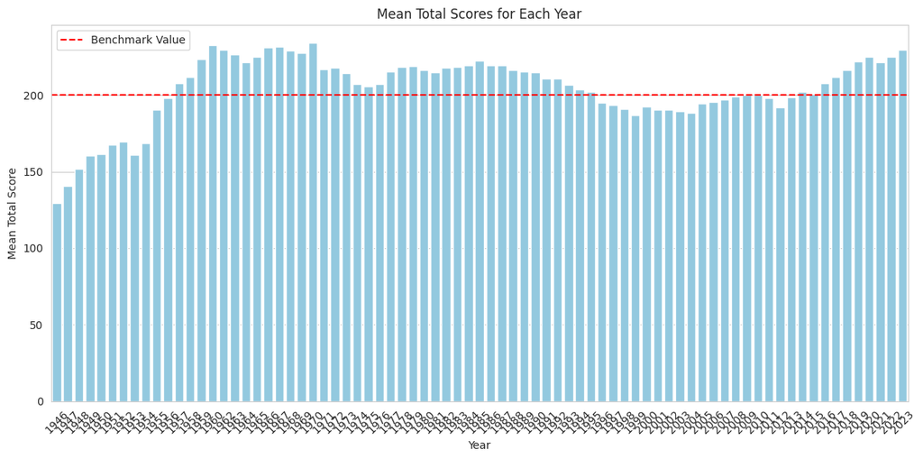

```python
import matplotlib.pyplot as plt
import seaborn as sns


benchmark_value = 200


plt.figure(figsize=(12, 6))
sns.set_style("whitegrid")


sns.barplot(x=df_years.index, y=df_years.values, color='skyblue')


plt.axhline(y=benchmark_value, color='red', linestyle='--', label='Benchmark Value')


alpha = 0.05
for year in df_years.index:
    t_stat, p_value = ttest_1samp(df_years.loc[year], benchmark_value)
    if p_value < alpha:
        plt.plot(year, df_years.loc[year], 'ro')


plt.xlabel('Year')
plt.ylabel('Mean Total Score')
plt.title('Mean Total Scores for Each Year')


plt.legend()


plt.xticks(rotation=45)
plt.tight_layout()
plt.show()
```

# **Primary Analysis and Visualization**

We initiate the process by leveraging seasonal decomposition from the statsmodels library to deconstruct the total points' time series into its constituent elements—trend, seasonal, and residual patterns. This enables us to uncover the underlying dynamics and fluctuations in NBA game scores, offering profound insights into the temporal trends shaping the basketball landscape.

Following this, we transition into predictive modeling, where we use linear regression to forecast total points based on the number of three-pointers made per game. After preparing the data and splitting it into training and testing sets, we train the regression model to capture the relationship between three-point shooting proficiency and overall game scores. By evaluating the model's performance using mean squared error and looking its coefficients and intercept, we gain invaluable insights into the predictive capabilities of our model and the factors influencing game outcomes.

Looking towards the future, we extend our analysis to make predictions for forthcoming dates in 2025, assuming different values for the number of three-pointers made per game. This forward-looking approach allows us to anticipate potential game outcomes and envisage the impact of varying three-point shooting performances on total points scored. Furthermore, we assess our model's historical predictive prowess by forecasting total points per game for past dates and comparing the predicted values with actual outcomes, providing a comprehensive evaluation of the model's accuracy and efficacy.

[output not shown]

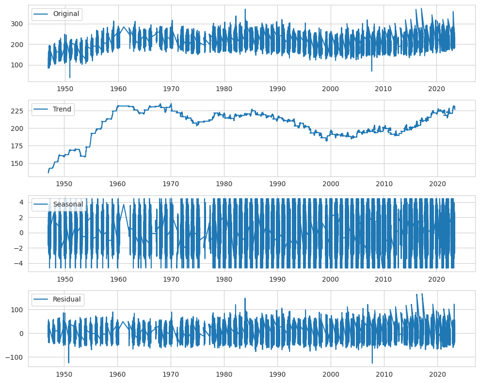

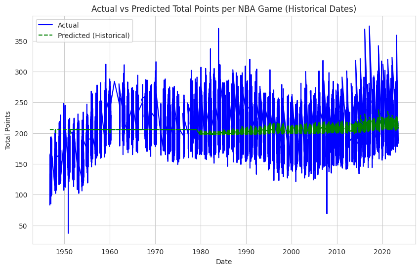

```python
import pandas as pd
import numpy as np
import matplotlib.pyplot as plt
from statsmodels.tsa.seasonal import seasonal_decompose
from sklearn.model_selection import train_test_split
from sklearn.linear_model import LinearRegression
from sklearn.metrics import mean_squared_error
from sklearn.impute import SimpleImputer


decomposition = seasonal_decompose(df['total_points'], model='additive', period=365)
trend = decomposition.trend
seasonal = decomposition.seasonal
residual = decomposition.resid

plt.figure(figsize=(10, 8))
plt.subplot(411)
plt.plot(df['game_date'], df['total_points'], label='Original')
plt.legend(loc='upper left')
plt.subplot(412)
plt.plot(df['game_date'], trend, label='Trend')
plt.legend(loc='upper left')
plt.subplot(413)
plt.plot(df['game_date'], seasonal, label='Seasonal')
plt.legend(loc='upper left')
plt.subplot(414)
plt.plot(df['game_date'], residual, label='Residual')
plt.legend(loc='upper left')
plt.tight_layout()


X = df[['3_pointers_made']]
y = df['total_points']


imputer = SimpleImputer(strategy='mean')
X_imputed = imputer.fit_transform(X)

X_train, X_test, y_train, y_test = train_test_split(X_imputed, y, test_size=0.2, random_state=42)

regression_model = LinearRegression()
regression_model.fit(X_train, y_train)


y_pred = regression_model.predict(X_test)

mse = mean_squared_error(y_test, y_pred)
print(f"Mean Squared Error: {mse}")


coefficients = regression_model.coef_
intercept = regression_model.intercept_
print(f"Coefficients: {coefficients}")
print(f"Intercept: {intercept}")


three_pointers_values = [20, 25, 30, 35, 40]

for value in three_pointers_values:
    future_dates = pd.date_range(start='2025-01-01', end='2025-01-05', freq='D')
    future_data = pd.DataFrame({'3_pointers_made': [value] * len(future_dates)}, index=future_dates)
    future_predictions = regression_model.predict(imputer.transform(future_data[['3_pointers_made']]))

    print(f"Future Predictions for 3-Pointers Made = {value}:")
    print(future_predictions)



past_predictions = regression_model.predict(X_imputed)

plt.figure(figsize=(10, 6))
plt.plot(df['game_date'], df['total_points'], label='Actual', color='blue')
plt.plot(df['game_date'], past_predictions, label='Predicted (Historical)', linestyle='--', color='green')
plt.xlabel('Date')
plt.ylabel('Total Points')
plt.title('Actual vs Predicted Total Points per NBA Game (Historical Dates)')
plt.legend()
plt.grid(True)
plt.show()
```

The predictions consistently hovering around the low 200's range suggest that our model may not capture the full variability and complexity of the total points scored in NBA games over time. This could be attributed to several factors, such as the simplicity of our linear regression model, which may not adequately capture non-linear relationships and other underlying factors influencing game scores. This makes sense because the Mean Squared Error (MSE) of approximately 639.64 is pretty high, suggesting that our model's predictions deviate significantly from the actual total points scored in NBA games.

# **Conclusions**

Based on the comprehensive analysis of historical NBA game data, several key insights have emerged regarding scoring trends and the evolution of three-point shooting in basketball.

```python
!pip install nbconvert
```

```python
!jupyter nbconvert --to html /content/Vinay Gundu- Final Deliverable Checkpoint3.ipynb
```

[output not shown]

[output cut: 137 more lines]

[output not shown]

```python
from google.colab import drive
drive.mount('/content/drive')
```